# Taiwo Judith Oyafajo 100984464

# Introduction:

John Snow’s groundbreaking work in 1854 is often celebrated as one of the earliest applications of data visualization to address a public health crisis. Faced with a cholera outbreak in London, Snow mapped the locations of cholera cases, eventually tracing the source to a contaminated water pump on Broad Street. His work not only saved lives but also demonstrated the power of visual data analysis in uncovering the root causes of public health issues.

For this assignment, we were asked to redesign a significant historical information graphic using contemporary, interactive methods. I chose to reimagine Snow’s cholera map, drawing on both the historical significance of the outbreak and my familiarity with the subject matter. The dataset I used was sourced from the Google Drive folder shared by Dr. Gabby.

```python
!pip install pandas matplotlib plotly geopandas folium
```

```python
import pandas as pd
import numpy as np
import matplotlib.path as mplPath
import matplotlib.pyplot as plt
import geopandas as gpd
import seaborn as sns
import folium
from folium.plugins import HeatMap
import shapely as shp
from shapely.geometry import Point, LineString, Polygon
```

```python
# Reading in the data
deaths = pd.read_csv("Data/deaths.csv")
pumps = pd.read_csv("Data/pumps.csv")
```

```python
#deaths data

print (deaths.head())

print (pumps.head())
```

```
   death_count  x_latitude  y_longitude
0            1   51.513418    -0.137930
1            1   51.513418    -0.137930
2            1   51.513418    -0.137930
3            1   51.513361    -0.137883
4            1   51.513361    -0.137883
        pump_name  x_coordinate  y_coordinate
0       Broad St.     51.513341     -0.136668
1    Crown Chapel     51.513876     -0.139586
2  Gt Marlborough     51.514906     -0.139671
3        Dean St.     51.512354     -0.131630
4         So Soho     51.512139     -0.133594
```

```python
import pandas as pd
import folium
from folium.plugins import HeatMap, MarkerCluster

# The snow map
deaths_df = pd.DataFrame({
    "death_count": [1, 1, 1, 1, 1],
    "x_latitude": [51.513418, 51.513418, 51.513418, 51.513361, 51.513361],
    "y_longitude": [-0.137930, -0.137930, -0.137930, -0.137883, -0.137883]
})
pumps_df = pd.DataFrame({
    "pump_name": ["Broad St.", "Crown Chapel", "Gt Marlborough", "Dean St.", "So Soho"],
    "x_coordinate": [51.513341, 51.513876, 51.514906, 51.512354, 51.512139],
    "y_coordinate": [-0.136668, -0.139586, -0.139671, -0.131630, -0.133594]
})
```

```python
# Initialize map centered on the outbreak location
m = folium.Map(location=[51.513, -0.137], zoom_start=16)

# Add death locations with heatmap
heat_data = list(zip(deaths_df['x_latitude'], deaths_df['y_longitude'], deaths_df['death_count']))
HeatMap(heat_data).add_to(m)

HeatMap(heat_data, radius=10, gradient={0.2: 'blue', 0.5: 'lime', 0.9: 'red'}).add_to(m)
```

```
<folium.plugins.heat_map.HeatMap at 0x1c391826a40>
```

```python
# Adding Pump Markers with toggling
pump_layer = folium.FeatureGroup(name="Water Pumps", show=True)
for _, row in pumps_df.iterrows():
    folium.Marker(
        location=[row['x_coordinate'], row['y_coordinate']],
        popup=f"<b>Pump Name:</b> {row['pump_name']}",
        tooltip="Click for Pump Info",
        icon=folium.Icon(color='blue', icon='info-sign')
    ).add_to(pump_layer)
pump_layer.add_to(m)
```

```
<folium.map.FeatureGroup at 0x1c397c1de40>
```

```python
# Adding Clustered Death Markers for Interactivity
marker_cluster = MarkerCluster(name="Cholera Cases").add_to(m)
for _, row in deaths_df.iterrows():
    folium.Marker(
        location=[row['x_latitude'], row['y_longitude']],
        popup=f"<b>Deaths:</b> {row['death_count']}",
        tooltip="Cholera Case"
    ).add_to(marker_cluster)
```

```python
# Adding Filters - Example Dropdown Filter by Case Density
folium.LayerControl().add_to(m)
```

```
<folium.map.LayerControl at 0x1c397c1cac0>
```

```python
# Historical Context: Adding Text/HTML Information
historical_note = """
<b>Historical Context:</b> John Snow's 1854 cholera map showed a clear correlation between cholera cases and the contaminated Broad Street pump.
"""
folium.Marker(
    [51.513, -0.137],
    icon=folium.DivIcon(html=f'<div style="font-size: 12pt; color : black">{historical_note}</div>')
).add_to(m)

# Display map
m
```

Make this Notebook Trusted to load map: File -> Trust Notebook

[interactive chart not shown]

# Initial Hand-drawn Sketch

The sketch below illustrates the foundational visualization concept for the cholera outbreak data. This initial design served as a blueprint for the interactive version, featuring dynamic components.

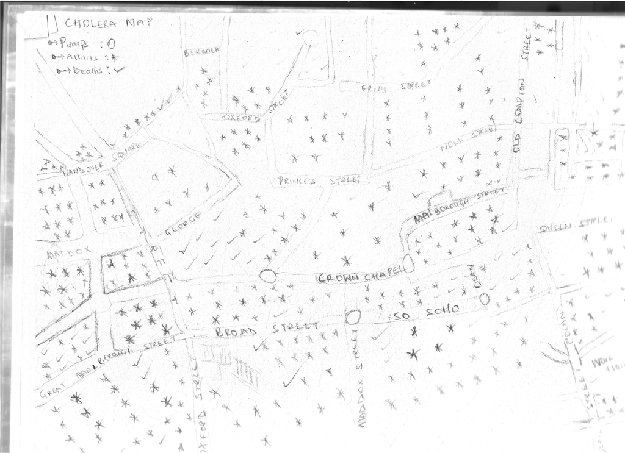

```python
from IPython.display import Image

Image(filename ='images/Sketch.jpg')
```

```python
#resources: Google, github.com/shukkkur,https://www.youtube.com/watch?v=KvHL0dHj3RM,
```